# DATA VISUALIZATION PROJECT

# MULTIVARIATE CATPLOT

**To analyse the number of vehicles that belong to different owner type and transmission with respect to their seats**

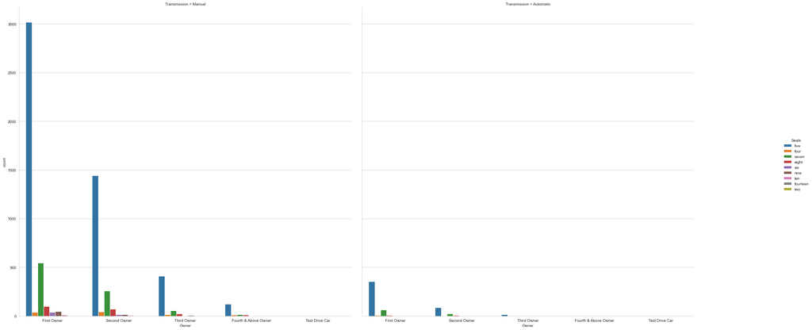

```python
x=sns.catplot(x='Owner',col='Transmission',hue='Seats',kind='count',data=car_ds)
x.fig.set_size_inches(30,15)
x.fig.subplots_adjust(top=0.81,right=0.86)
```

# INFERENCE:

**The above countplot shows that five seater vehicles that are owned by first owners and are manual is more compared to others**

# MULTIVARIATE PAIR PLOT

**To analyze the pairwise relationship of all the numerical attributes in the dataset pairplot is used**

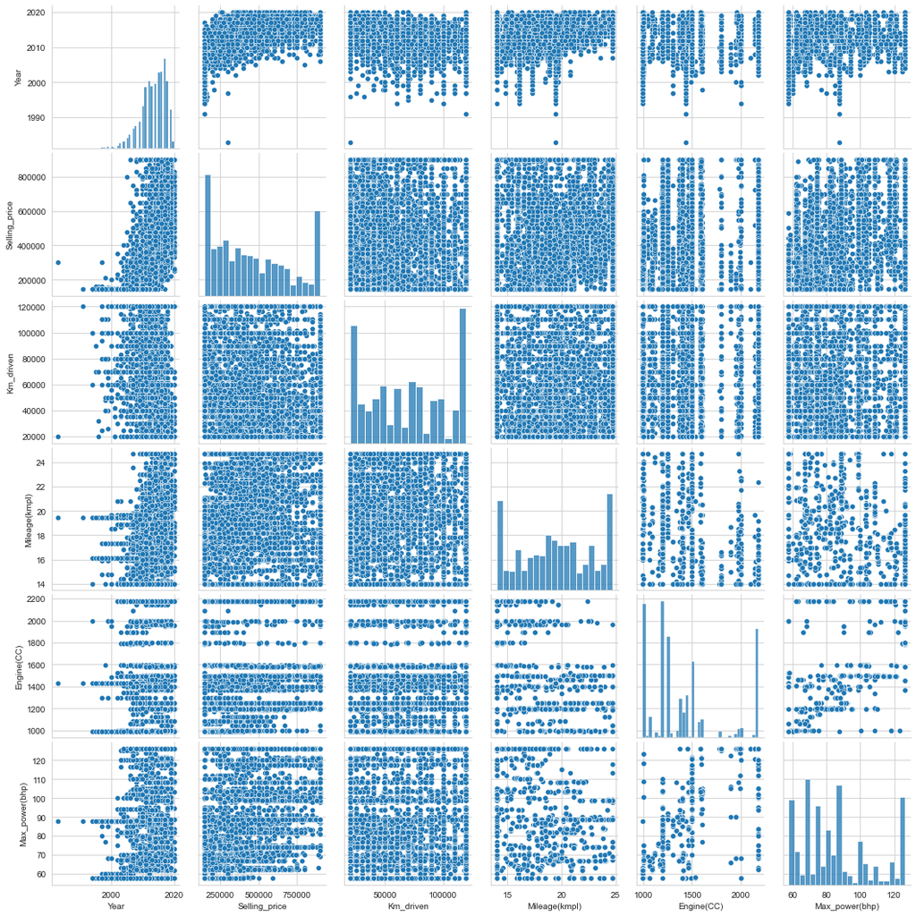

```python
sns.pairplot(car_ds)
```

# MULTIVARIATE HEAT MAP

**To analyze the correlation between each and every attribute in the dataset heatmap is used. Darker the shade, more is the correlation. Here dark blue shade represents higher correlation for that particular variables. Pale yellow represents lower correlation.**

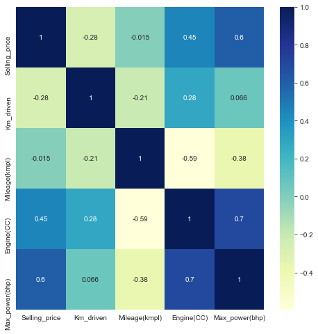

```python
fig,ax=plt.subplots(figsize = (8,8))
x=car_ds.corr()
sns.heatmap(x,annot=True,cmap='YlGnBu')
```

# INFERENCE:

**The above heatmap shows that Max_power(bhp) and Engine(CC) have more correlation while Selling_price and Mileage have the least correlation**

# MACHINE LEARNING ALGORITHM IMPLEMENTATION TO PREDICT SELLING PRICE

```python
accuracy=[]
model=[]
```

```python
from sklearn.model_selection import train_test_split
from sklearn.metrics import accuracy_score
from sklearn.metrics import r2_score
```

```python
x=car_ds[['Mileage(kmpl)','Engine(CC)','Km_driven','Max_power(bhp)','Year']]
y=car_ds['Selling_price']
x_ip_train,x_ip_test,y_dp_train,y_dp_test=train_test_split(x,y,test_size=0.1)
```

# DECISION TREE

```python
from sklearn.tree import DecisionTreeRegressor

DTree=DecisionTreeRegressor(min_samples_leaf=.01)
DTree.fit(x_ip_train,y_dp_train)
y_predicted=DTree.predict(x_ip_test)
r_value=r2_score(y_dp_test,y_predicted)*100

accuracy.append(r_value)
model.append('Decision Tree')

print("Accuracy of Decision Tree Regressor: ",r_value)
print(" ")

df=pd.DataFrame({'y':y_dp_test,'y_predicted':y_predicted})
df
```

```
Accuracy of Decision Tree Regressor:  80.91784553679211
```

|  | y | y_predicted |
| --- | --- | --- |
| 1573 | 550000 | 460257.366337 |
| 312 | 900000 | 742750.000000 |
| 4124 | 625000 | 628744.648936 |
| 6293 | 625000 | 638189.171171 |
| 3536 | 345000 | 431757.500000 |
| ... | ... | ... |
| 2793 | 250000 | 217690.428571 |
| 6853 | 434000 | 545841.056075 |
| 2724 | 220000 | 270142.845238 |
| 1801 | 220000 | 234478.195652 |
| 3222 | 280000 | 309543.434783 |

693 rows × 2 columns

```
The difference between the actual y value and y predicted value:
```

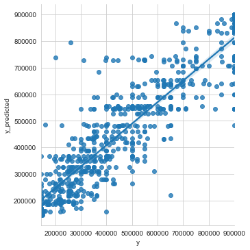

```python
print("The difference between the actual y value and y predicted value:")
sns.lmplot('y','y_predicted',data=df)
```

# RANDOM FOREST

```python
from sklearn.ensemble import RandomForestRegressor

r_f=RandomForestRegressor()
r_f.fit(x_ip_train,y_dp_train)
y_predicted=r_f.predict(x_ip_test)
r_value=r2_score(y_dp_test,y_predicted)*100

accuracy.append(r_value)
model.append('Random Forest')

print("Accuracy of Random Forest Regressor: ",r_value)
print(" ")

df=pd.DataFrame({'y':y_dp_test,'y_predicted':y_predicted})
df
```

```
Accuracy of Random Forest Regressor:  89.39080840174698
```

|  | y | y_predicted |
| --- | --- | --- |
| 1573 | 550000 | 533139.980000 |
| 312 | 900000 | 850500.000000 |
| 4124 | 625000 | 651972.010476 |
| 6293 | 625000 | 531470.786667 |
| 3536 | 345000 | 420318.271667 |
| ... | ... | ... |
| 2793 | 250000 | 260520.743333 |
| 6853 | 434000 | 531672.583333 |
| 2724 | 220000 | 278944.961429 |
| 1801 | 220000 | 252049.404762 |
| 3222 | 280000 | 303347.380952 |

693 rows × 2 columns

```
The difference between the actual y value and y predicted value:
```

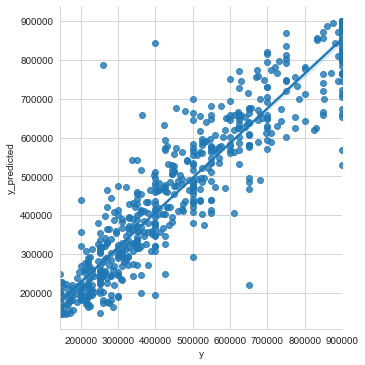

```python
sns.lmplot('y','y_predicted',data=df)
print("The difference between the actual y value and y predicted value:")
```

```python
ml=pd.DataFrame(list(zip(model,accuracy)),columns=["Algorithms","Precision"])
ml
```

|  | Algorithms | Precision |
| --- | --- | --- |
| 0 | Decision Tree | 80.917846 |
| 1 | Random Forest | 89.390808 |

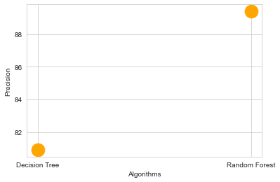

```python
ml.plot.scatter(x="Algorithms",y="Precision",s=350,c="orange")
plt.show()
```

# INFERENCE:

**Random forest algorithm gives more accuracy than decision tree.**